DS 6030 | Fall 2023 | University of Virginia

# Homework #5: SVM and Calibration

Author

Published

October 6, 2023

# Required R packages and Directories

```r
dir_data= 'https://mdporter.github.io/DS6030/data/' # data directory
library(tidyverse)  # functions for data manipulation
```

# COMPAS Recidivism Prediction

A recidivism risk model called COMPAS was the topic of a [ProPublica article](https://www.propublica.org/article/machine-bias-risk-assessments-in-criminal-sentencing/) on ML bias. Because the data and notebooks used for article was released on [github](https://github.com/propublica/compas-analysis), we can also evaluate the prediction bias (i.e., calibration).

This code will read in the *violent crime* risk score and apply the filtering used in the [analysis](https://github.com/propublica/compas-analysis/blob/master/Compas%20Analysis.ipynb).

```r
library(tidyverse)
df = read_csv("https://raw.githubusercontent.com/propublica/compas-analysis/master/compas-scores-two-years-violent.csv")

risk = df %>%
  filter(days_b_screening_arrest <= 30) %>%
  filter(days_b_screening_arrest >= -30) %>%
  filter(is_recid != -1) %>%
  filter(c_charge_degree != "O") %>%
  filter(v_score_text != 'N/A') %>%
  transmute(
    age, age_cat,
    charge = ifelse(c_charge_degree == "F", "Felony", "Misdemeanor"),
    race,
    sex,
    priors_count = priors_count...15,
    score = v_decile_score,              # the risk score {1,2,...,10}
    outcome = two_year_recid...53        # outcome {1 = two year recidivate}
  )
```

The `risk` data frame has the relevant information for completing the problems.

# Problem 1: COMPAS risk score

## a. Risk Score and Probability (table)

Assess the predictive bias in the COMPAS risk scores by evaluating the probability of recidivism, e.g. estimate $\Pr(Y = 1 \mid \text{Score}=x)$. Use any reasonable techniques (including Bayesian) to estimate the probability of recidivism for each risk score.

Specifically, create a table (e.g., data frame) that provides the following information:

- The COMPASS risk score.
- The point estimate of the probability of recidivism for each risk score.
- 95% confidence or credible intervals for the probability (e.g., Using normal theory, bootstrap, or Bayesian techniques).

Indicate the choices you made in estimation (e.g., state the prior if you used Bayesian methods).

**Solution**

```r
set.seed(6896)
test = sample(nrow(risk), size=750)
train = -test
```

```r
#: fit logistic regression model on training data
fit_lr = glm(outcome~., family='binomial', data = risk[train,])
```

```r
tbl_lr = risk[test,] %>%
  mutate(g = factor(outcome, c(0,1)),
         p_hat = predict(fit_lr, ., type="response"))
```

```r
tbl_score = tbl_lr %>%
  group_by(score) %>%
  summarize(n = n(), lower = min(p_hat), upper = max(p_hat),
            p_hat = mean(p_hat), n_y = sum(outcome),
            # bayesian (uniform prior)
            p_y = (n_y+1) / (n+2), # posterior mean
            beta_lower = qbeta(.025, n_y+1, n-n_y+1),
            beta_upper = qbeta(.975, n_y+1, n-n_y+1))
```

```r
tbl_score %>%
  select(score,p_y,beta_lower,beta_upper)
```

```
# A tibble: 10 × 4
  score    p_y beta_lower beta_upper
  <dbl>  <dbl>      <dbl>      <dbl>
1     1 0.0692     0.0417      0.103
2     2 0.0796     0.0374      0.136
3     3 0.179      0.114       0.254
4     4 0.173      0.0970      0.266
5     5 0.3        0.192       0.421
6     6 0.283      0.164       0.419
# ℹ 4 more rows
```

Since the data is binary, I was aiming for a beta prior distribution. I hope I did it right :)

## b. Risk Score and Probability (plot)

Make a plot of the risk scores and corresponding estimated probability of recidivism.

- Put the risk score on the x-axis and estimate probability of recidivism on y-axis.
- Add the 95% confidence or credible intervals calculated in part a.
- Comment on the patterns you see.

**Solution**

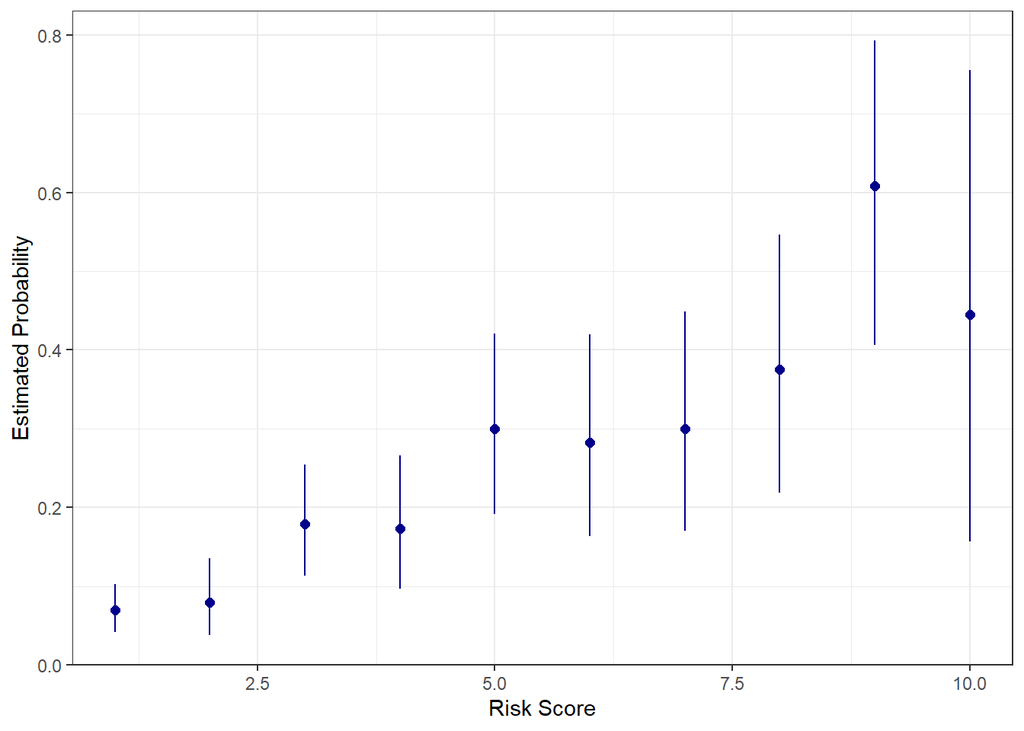

```r
tbl_score %>%
  ggplot(aes(x=score, y=p_y, ymin=beta_lower, ymax=beta_upper))+
  geom_pointrange(color="darkblue", size=0.1)+
  geom_point(color="darkblue", size=2)+
  labs(x = "Risk Score", y = "Estimated Probability")
```

Based on this graph, it seems like those with a higher “risk” score (I’m guessing it’s a score related to how likely the person is to commit another crime?) have a higher probability to actually commit another crime.

## c. Risk Score and Probability (by race)

Repeat the analysis, but this time do so for every race. Produce a set of plots (one per race) and comment on the patterns.

**Solution**

```r
tbl_race = tbl_lr %>%
  group_by(score, race) %>%
  summarize(n = n(), lower = min(p_hat), upper = max(p_hat),
            p_hat = mean(p_hat), n_y = sum(outcome),
            # bayesian (uniform prior)
            p_y = (n_y+1) / (n+2), # posterior mean
            beta_lower = qbeta(.025, n_y+1, n-n_y+1),
            beta_upper = qbeta(.975, n_y+1, n-n_y+1))
```

```r
tbl_race %>%
  select(score, race, p_y, beta_lower, beta_upper)
```

```
# A tibble: 42 × 5
# Groups:   score [10]
  score race                p_y beta_lower beta_upper
  <dbl> <chr>             <dbl>      <dbl>      <dbl>
1     1 African-American 0.105     0.0496       0.177
2     1 Asian            0.143     0.00421      0.459
3     1 Caucasian        0.0609    0.0250       0.111
4     1 Hispanic         0.0513    0.00644      0.138
5     1 Other            0.143     0.0321       0.317
6     2 African-American 0.118     0.0453       0.218
# ℹ 36 more rows
```

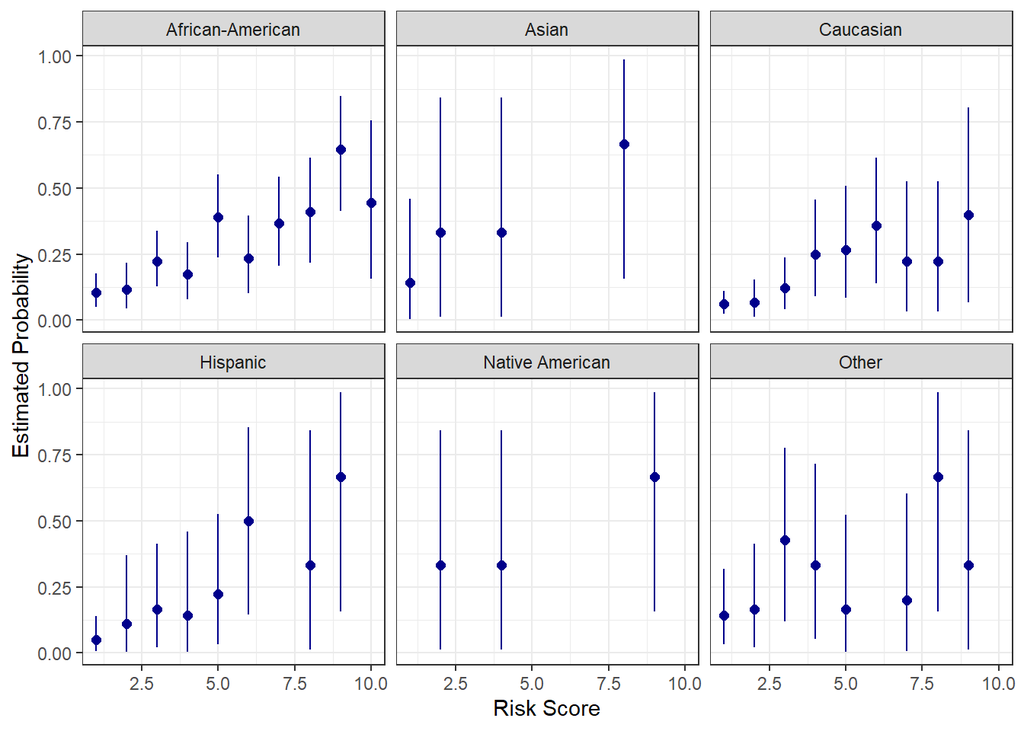

```r
tbl_race %>%
  ggplot(aes(x=score, y=p_y, ymin=beta_lower, ymax=beta_upper))+
  geom_pointrange(color="darkblue", size=0.1)+
  geom_point(color="darkblue", size=2)+
  labs(x = "Risk Score", y = "Estimated Probability")+
  facet_wrap(~race)
```

It looks like that regardless of race, the risk score is positively correlated with commiting another crime (or is it the same crime? idk).

## d. ROC Curves

Use the raw COMPAS risk scores to make a ROC curve for each race.

- Are the best discriminating models the ones you expected?
- Are the ROC curves helpful in evaluating the COMPAS risk score?

**Solution**

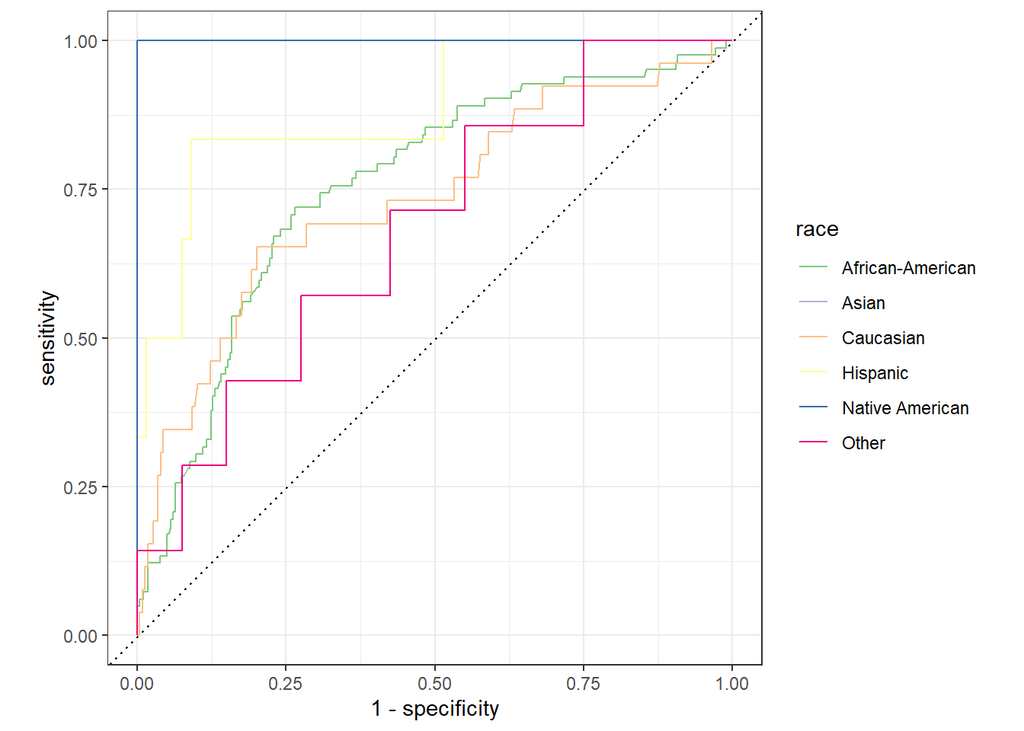

```r
library(yardstick)
tbl_lr %>% group_by(race) %>%
  roc_curve(truth = g, p_hat, event_level="second") %>%
  autoplot()+
  scale_color_brewer(type = "qual")
```

I think I’m not surprised about which models did the best in terms of the ROC curve.

# Problem 2: Support Vector Machines (SVM).

Focus on Problem 1, we won’t have an SVM problem this week.